# Final analysis only Expert.rmd

group 3

7/20/2019

# Instructions

## Required R packages

- `tidyverse` (or `ggplot2`, `dplyr`, `purrr`, `tibble`)
- `brms`
- `devtools` (for installing `faintr`)
- `rstan`
- `faintr` (install with `devtools`)

Load the required packages and set a seed for the random number generator.

```r
library(tidyverse)
library(rstan)
# set cores to use to the total number of cores (minimally 4)
options(mc.cores = max(parallel::detectCores(), 4))
# save a compiled version of the Stan model file
rstan_options(auto_write = TRUE)
library(brms)
# install faintr with devtools::install_github('michael-franke/bayes_mixed_regression_tutorial/faintr', build_vignettes = TRUE))
library(faintr)
set.seed(123)
```

## Step 1. Read the data and take a glimpse of it.

```r
data_raw <- read_csv("results_71_givemegestalt_group3_group3.csv")
glimpse(data_raw)
```

```
## Observations: 12,078
## Variables: 24
## $ submission_id  <dbl> 566, 566, 566, 566, 566, 566, 566, 566, 566, 56...
## $ QUD            <lgl> NA, NA, NA, NA, NA, NA, NA, NA, NA, NA, NA, NA,...
## $ RT             <dbl> 57807, 13595, 14410, 4927, 4493, 2380, 2907, 66...
## $ age            <dbl> 20, 20, 20, 20, 20, 20, 20, 20, 20, 20, 20, 20,...
## $ comments       <chr> NA, NA, NA, NA, NA, NA, NA, NA, NA, NA, NA, NA,...
## $ endTime        <dbl> 1.562946e+12, 1.562946e+12, 1.562946e+12, 1.562...
## $ experiment_id  <dbl> 71, 71, 71, 71, 71, 71, 71, 71, 71, 71, 71, 71,...
## $ fileID         <dbl> NA, NA, 26, 3, 11, 4, 22, 33, 17, 60, 23, 59, 5...
## $ gender         <chr> "female", "female", "female", "female", "female...
## $ is_expert      <chr> "No", "No", "No", "No", "No", "No", "No", "No",...
## $ min_chars      <dbl> 0, NA, NA, NA, NA, NA, NA, NA, NA, NA, NA, NA, ...
## $ option1        <chr> NA, "Yes", NA, NA, NA, NA, NA, NA, NA, NA, NA, ...
## $ option2        <chr> NA, "No", NA, NA, NA, NA, NA, NA, NA, NA, NA, N...
## $ optionLeft     <chr> NA, NA, "not at all", "not at all", "not at all...
## $ optionRight    <chr> NA, NA, "very much", "very much", "very much", ...
## $ picture        <chr> "images/snellen/snellen.png", NA, "images/stimu...
## $ question       <chr> "Which row is the last one where you can recogn...
## $ response       <chr> "9", "No", "6", "5", "3", "3", "1", "5", "4", "...
## $ snellen_result <dbl> 9, 9, 9, 9, 9, 9, 9, 9, 9, 9, 9, 9, 9, 9, 9, 9,...
## $ startDate      <chr> "Fri Jul 12 2019 17:34:17 GMT+0200 (Mitteleurop...
## $ startTime      <dbl> 1.562946e+12, 1.562946e+12, 1.562946e+12, 1.562...
## $ timeSpent      <dbl> 11.90795, 11.90795, 11.90795, 11.90795, 11.9079...
## $ trial_name     <chr> "test_snellen", "b0_expert", "b1_exp", "b1_exp"...
## $ trial_number   <dbl> 1, 1, 1, 2, 3, 4, 5, 6, 7, 8, 9, 10, 11, 12, 13...
```

Step 2. Select only the columns of interest and filter trials that are not interesting for the calculations. Change data type of the responses to double and submission_id to factor. Detect outliers. —

```r
data_selection <- select(data_raw, submission_id, snellen_result, is_expert, age, gender, trial_name, trial_number, fileID, response, RT, timeSpent, comments)
data_filtered <- filter(data_selection, trial_name != "test_snellen", trial_name != "b0_expert")
data_mut <- mutate(data_filtered, response = as.double(response), submission_id = factor(submission_id))
show(data_selection)
```

```
## # A tibble: 12,078 x 12
##    submission_id snellen_result is_expert   age gender trial_name
##            <dbl>          <dbl> <chr>     <dbl> <chr>  <chr>
##  1           566              9 No           20 female test_snel~
##  2           566              9 No           20 female b0_expert
##  3           566              9 No           20 female b1_exp
##  4           566              9 No           20 female b1_exp
##  5           566              9 No           20 female b1_exp
##  6           566              9 No           20 female b1_exp
##  7           566              9 No           20 female b1_exp
##  8           566              9 No           20 female b1_exp
##  9           566              9 No           20 female b1_exp
## 10           566              9 No           20 female b1_exp
## # ... with 12,068 more rows, and 6 more variables: trial_number <dbl>,
## #   fileID <dbl>, response <chr>, RT <dbl>, timeSpent <dbl>,
## #   comments <chr>
```

```r
show(data_filtered)
```

```
## # A tibble: 11,880 x 12
##    submission_id snellen_result is_expert   age gender trial_name
##            <dbl>          <dbl> <chr>     <dbl> <chr>  <chr>
##  1           566              9 No           20 female b1_exp
##  2           566              9 No           20 female b1_exp
##  3           566              9 No           20 female b1_exp
##  4           566              9 No           20 female b1_exp
##  5           566              9 No           20 female b1_exp
##  6           566              9 No           20 female b1_exp
##  7           566              9 No           20 female b1_exp
##  8           566              9 No           20 female b1_exp
##  9           566              9 No           20 female b1_exp
## 10           566              9 No           20 female b1_exp
## # ... with 11,870 more rows, and 6 more variables: trial_number <dbl>,
## #   fileID <dbl>, response <chr>, RT <dbl>, timeSpent <dbl>,
## #   comments <chr>
```

```r
show(data_mut)
```

```
## # A tibble: 11,880 x 12
##    submission_id snellen_result is_expert   age gender trial_name
##    <fct>                  <dbl> <chr>     <dbl> <chr>  <chr>
##  1 566                        9 No           20 female b1_exp
##  2 566                        9 No           20 female b1_exp
##  3 566                        9 No           20 female b1_exp
##  4 566                        9 No           20 female b1_exp
##  5 566                        9 No           20 female b1_exp
##  6 566                        9 No           20 female b1_exp
##  7 566                        9 No           20 female b1_exp
##  8 566                        9 No           20 female b1_exp
##  9 566                        9 No           20 female b1_exp
## 10 566                        9 No           20 female b1_exp
## # ... with 11,870 more rows, and 6 more variables: trial_number <dbl>,
## #   fileID <dbl>, response <dbl>, RT <dbl>, timeSpent <dbl>,
## #   comments <chr>
```

```r
# 3 participants only rated "1" in both blocks, one participant only rated "7", one gave a invalid input for the Snellen test, we exclude them:
data_clean <- filter(data_mut, submission_id != 607, submission_id != 736, submission_id != 475, submission_id != 480, submission_id != 726)
show(data_clean)
```

```
## # A tibble: 11,280 x 12
##    submission_id snellen_result is_expert   age gender trial_name
##    <fct>                  <dbl> <chr>     <dbl> <chr>  <chr>
##  1 566                        9 No           20 female b1_exp
##  2 566                        9 No           20 female b1_exp
##  3 566                        9 No           20 female b1_exp
##  4 566                        9 No           20 female b1_exp
##  5 566                        9 No           20 female b1_exp
##  6 566                        9 No           20 female b1_exp
##  7 566                        9 No           20 female b1_exp
##  8 566                        9 No           20 female b1_exp
##  9 566                        9 No           20 female b1_exp
## 10 566                        9 No           20 female b1_exp
## # ... with 11,270 more rows, and 6 more variables: trial_number <dbl>,
## #   fileID <dbl>, response <dbl>, RT <dbl>, timeSpent <dbl>,
## #   comments <chr>
```

## Demografics

```r
data_rawdemografics <- select(data_clean, submission_id, age, gender, is_expert, snellen_result, comments)
data_demografics <- dplyr::distinct(group_by(data_rawdemografics, submission_id))
show(data_demografics[order(data_demografics$submission_id),])
```

```
## # A tibble: 94 x 6
## # Groups:   submission_id [94]
##    submission_id   age gender is_expert snellen_result comments
##    <fct>         <dbl> <chr>  <chr>              <dbl> <chr>
##  1 458              51 male   Yes                    9 <NA>
##  2 459              20 female Yes                    9 <NA>
##  3 460              18 female No                     9 <NA>
##  4 461              63 male   No                    10 <NA>
##  5 462              29 female No                     9 <NA>
##  6 463              56 female No                     7 <NA>
##  7 464              21 female No                    10 <NA>
##  8 465              21 female No                     9 <NA>
##  9 466              19 female No                     8 <NA>
## 10 467              23 male   No                    10 <NA>
## # ... with 84 more rows
```

Total number of participents:

```r
length(unique(data_clean$submission_id))
```

```
## [1] 94
```

Detecting the gender data provided and their count:

```r
data_gender_male <- filter(data_clean,gender == "male")
data_gender_female <- filter(data_clean,gender == "female")
data_gender_diverse <- filter(data_clean,gender == "divers")
length(data_gender_male$gender)/120
```

```
## [1] 33
```

```r
length(data_gender_female$gender)/120
```

```
## [1] 57
```

```r
length(data_gender_diverse$gender)/120
```

```
## [1] 2
```

```r
sum(is.na(data_clean$gender))/120 # counting how many NA are there.
```

```
## [1] 2
```

There are total 33 male participents, 57 female and 2 of them identify teir gender as diverse and 2 of them did not submitted the data about gender.

Data set according to age :

```r
data_age_below_20 <- filter(data_clean,age <= 19)
data_age_20_40<-filter(data_clean,age>=20&age<=40)
data_age_ab_40 <- filter(data_clean,age > 40)
#divide by 120 because there are 120 entries per person
length(data_age_below_20$age)/120
```

```
## [1] 14
```

```r
length(data_age_20_40$age)/120
```

```
## [1] 69
```

```r
length(data_age_ab_40$age)/120
```

```
## [1] 10
```

```r
sum(is.na(data_clean$age))/120
```

```
## [1] 1
```

From total participants there are total 14 participants, who are below age of 20, 69 are in range of 20 - 40 and 10 are in range of 41 to 63. 1 participants did not give data for age.

Step 3. Filter participants that are experts. explit data according to trial (b1: Liking, b2: Detactability). — This analysis tells us something about the correlation in experts.

```r
# Data for experts
data_exp <- filter(data_clean, is_expert == "Yes")
b1_exp <- filter(data_exp, trial_name == "b1_exp")
b2_exp <- filter(data_exp, trial_name == "b2_exp")
show(b1_exp)
```

```
## # A tibble: 540 x 12
##    submission_id snellen_result is_expert   age gender trial_name
##    <fct>                  <dbl> <chr>     <dbl> <chr>  <chr>
##  1 613                        8 Yes          42 male   b1_exp
##  2 613                        8 Yes          42 male   b1_exp
##  3 613                        8 Yes          42 male   b1_exp
##  4 613                        8 Yes          42 male   b1_exp
##  5 613                        8 Yes          42 male   b1_exp
##  6 613                        8 Yes          42 male   b1_exp
##  7 613                        8 Yes          42 male   b1_exp
##  8 613                        8 Yes          42 male   b1_exp
##  9 613                        8 Yes          42 male   b1_exp
## 10 613                        8 Yes          42 male   b1_exp
## # ... with 530 more rows, and 6 more variables: trial_number <dbl>,
## #   fileID <dbl>, response <dbl>, RT <dbl>, timeSpent <dbl>,
## #   comments <chr>
```

```r
show(b2_exp)
```

```
## # A tibble: 540 x 12
##    submission_id snellen_result is_expert   age gender trial_name
##    <fct>                  <dbl> <chr>     <dbl> <chr>  <chr>
##  1 613                        8 Yes          42 male   b2_exp
##  2 613                        8 Yes          42 male   b2_exp
##  3 613                        8 Yes          42 male   b2_exp
##  4 613                        8 Yes          42 male   b2_exp
##  5 613                        8 Yes          42 male   b2_exp
##  6 613                        8 Yes          42 male   b2_exp
##  7 613                        8 Yes          42 male   b2_exp
##  8 613                        8 Yes          42 male   b2_exp
##  9 613                        8 Yes          42 male   b2_exp
## 10 613                        8 Yes          42 male   b2_exp
## # ... with 530 more rows, and 6 more variables: trial_number <dbl>,
## #   fileID <dbl>, response <dbl>, RT <dbl>, timeSpent <dbl>,
## #   comments <chr>
```

Step 4. Average data. Generate table with needed non-aggregated data in useful format.

```r
# Averaged data:
b1_exp_mean <- group_by(b1_exp, fileID) %>% summarise(mean_Like_exp = mean(response))
b2_exp_mean <- group_by(b2_exp, fileID) %>% summarise(mean_Detect_exp = mean(response))
show(b1_exp_mean)
```

```
## # A tibble: 60 x 2
##    fileID mean_Like_exp
##     <dbl>         <dbl>
##  1      1          4
##  2      2          4.56
##  3      3          3.78
##  4      4          2.89
##  5      5          3.33
##  6      6          4.33
##  7      7          3.78
##  8      8          3.22
##  9      9          3.44
## 10     10          4.56
## # ... with 50 more rows
```

```r
show(b2_exp_mean)
```

```
## # A tibble: 60 x 2
##    fileID mean_Detect_exp
##     <dbl>           <dbl>
##  1      1            4.33
##  2      2            4.33
##  3      3            3.11
##  4      4            2.56
##  5      5            3.33
##  6      6            4.33
##  7      7            4.11
##  8      8            3.56
##  9      9            3
## 10     10            3.89
## # ... with 50 more rows
```

```r
final_exp_mean <- merge(x = b2_exp_mean, y = b1_exp_mean, by = "fileID")
show(final_exp_mean)
```

```
##    fileID mean_Detect_exp mean_Like_exp
## 1       1        4.333333      4.000000
## 2       2        4.333333      4.555556
## 3       3        3.111111      3.777778
## 4       4        2.555556      2.888889
## 5       5        3.333333      3.333333
## 6       6        4.333333      4.333333
## 7       7        4.111111      3.777778
## 8       8        3.555556      3.222222
## 9       9        3.000000      3.444444
## 10     10        3.888889      4.555556
## 11     11        3.222222      4.111111
## 12     12        4.555556      4.555556
## 13     13        3.777778      3.888889
## 14     14        3.111111      3.000000
```

[output cut: 46 more lines]

```r
# Non-average data:
b1_exp_mutated <- mutate(b1_exp, liking_exp = response, RT_liking = RT)
b2_exp_mutated <- mutate(b2_exp, detectability_exp = response, RT_detectability = RT)
b1_exp_selected <- select(b1_exp_mutated, fileID, submission_id, age, snellen_result, timeSpent, liking_exp, RT_liking)
b2_exp_selected <- select(b2_exp_mutated, fileID, submission_id, age, snellen_result, timeSpent, detectability_exp, RT_detectability)
b1_exp_orderd <- b1_exp_selected[order(b1_exp_selected$fileID),]
b2_exp_orderd <- b2_exp_selected[order(b2_exp_selected$fileID),]
merged_exp_data <- b1_exp_orderd
merged_exp_data$detectability_exp <- b2_exp_orderd$detectability_exp
merged_exp_data$RT_detectability <- b2_exp_orderd$RT_detectability
show(b1_exp_selected)
```

```
## # A tibble: 540 x 7
##    fileID submission_id   age snellen_result timeSpent liking_exp RT_liking
##     <dbl> <fct>         <dbl>          <dbl>     <dbl>      <dbl>     <dbl>
##  1     14 613              42              8      9.23          7     16310
##  2     13 613              42              8      9.23          7      3436
##  3     30 613              42              8      9.23          6      7470
##  4     39 613              42              8      9.23          5      3522
##  5      1 613              42              8      9.23          7      5105
##  6     37 613              42              8      9.23          7      2984
##  7     56 613              42              8      9.23          5      3498
##  8      9 613              42              8      9.23          4      5635
##  9      2 613              42              8      9.23          2      4060
## 10     36 613              42              8      9.23          4      4330
## # ... with 530 more rows
```

```r
show(b2_exp_selected)
```

```
## # A tibble: 540 x 7
##    fileID submission_id   age snellen_result timeSpent detectability_e~
##     <dbl> <fct>         <dbl>          <dbl>     <dbl>            <dbl>
##  1     48 613              42              8      9.23                3
##  2     16 613              42              8      9.23                3
##  3     11 613              42              8      9.23                4
##  4     51 613              42              8      9.23                6
##  5     33 613              42              8      9.23                6
##  6     52 613              42              8      9.23                4
##  7     42 613              42              8      9.23                4
##  8     50 613              42              8      9.23                2
##  9     46 613              42              8      9.23                3
## 10      6 613              42              8      9.23                7
## # ... with 530 more rows, and 1 more variable: RT_detectability <dbl>
```

```r
show(b1_exp_orderd)
```

```
## # A tibble: 540 x 7
##    fileID submission_id   age snellen_result timeSpent liking_exp RT_liking
##     <dbl> <fct>         <dbl>          <dbl>     <dbl>      <dbl>     <dbl>
##  1      1 613              42              8      9.23          7      5105
##  2      1 547              20             10     39.7           1      6883
##  3      1 620              21              8     10.5           3      4024
##  4      1 742              28             10      9.33          4      4084
##  5      1 753              27              7     12.9           3     14442
##  6      1 755              13             10     11.6           6      3319
##  7      1 458              51              9      8.50          4      2465
##  8      1 459              20              9      4.71          4       836
##  9      1 479              26              4      7.92          4      3064
## 10      2 613              42              8      9.23          2      4060
## # ... with 530 more rows
```

```r
show(b2_exp_orderd)
```

```
## # A tibble: 540 x 7
##    fileID submission_id   age snellen_result timeSpent detectability_e~
##     <dbl> <fct>         <dbl>          <dbl>     <dbl>            <dbl>
##  1      1 613              42              8      9.23                7
##  2      1 547              20             10     39.7                 1
##  3      1 620              21              8     10.5                 3
##  4      1 742              28             10      9.33                6
##  5      1 753              27              7     12.9                 4
##  6      1 755              13             10     11.6                 5
##  7      1 458              51              9      8.50                5
##  8      1 459              20              9      4.71                5
##  9      1 479              26              4      7.92                3
## 10      2 613              42              8      9.23                5
## # ... with 530 more rows, and 1 more variable: RT_detectability <dbl>
```

```r
show(merged_exp_data)
```

```
## # A tibble: 540 x 9
##    fileID submission_id   age snellen_result timeSpent liking_exp RT_liking
##     <dbl> <fct>         <dbl>          <dbl>     <dbl>      <dbl>     <dbl>
##  1      1 613              42              8      9.23          7      5105
##  2      1 547              20             10     39.7           1      6883
##  3      1 620              21              8     10.5           3      4024
##  4      1 742              28             10      9.33          4      4084
##  5      1 753              27              7     12.9           3     14442
##  6      1 755              13             10     11.6           6      3319
##  7      1 458              51              9      8.50          4      2465
##  8      1 459              20              9      4.71          4       836
##  9      1 479              26              4      7.92          4      3064
## 10      2 613              42              8      9.23          2      4060
## # ... with 530 more rows, and 2 more variables: detectability_exp <dbl>,
## #   RT_detectability <dbl>
```

```r
final_exp <- as_tibble(merged_exp_data)
show(final_exp)
```

```
## # A tibble: 540 x 9
##    fileID submission_id   age snellen_result timeSpent liking_exp RT_liking
##     <dbl> <fct>         <dbl>          <dbl>     <dbl>      <dbl>     <dbl>
##  1      1 613              42              8      9.23          7      5105
##  2      1 547              20             10     39.7           1      6883
##  3      1 620              21              8     10.5           3      4024
##  4      1 742              28             10      9.33          4      4084
##  5      1 753              27              7     12.9           3     14442
##  6      1 755              13             10     11.6           6      3319
##  7      1 458              51              9      8.50          4      2465
##  8      1 459              20              9      4.71          4       836
##  9      1 479              26              4      7.92          4      3064
## 10      2 613              42              8      9.23          2      4060
## # ... with 530 more rows, and 2 more variables: detectability_exp <dbl>,
## #   RT_detectability <dbl>
```

## Step 5.Test assumptions for linear regression.

Normality:

```r
# Non-averaged data:
ks.test(b1_exp$response, pnorm)
```

```
##
##  One-sample Kolmogorov-Smirnov test
##
## data:  b1_exp$response
## D = 0.91614, p-value < 2.2e-16
## alternative hypothesis: two-sided
```

```r
ks.test(b2_exp$response, pnorm)
```

```
##
##  One-sample Kolmogorov-Smirnov test
##
## data:  b2_exp$response
## D = 0.86799, p-value < 2.2e-16
## alternative hypothesis: two-sided
```

```r
# Averaged data:
ks.test(b1_exp_mean$mean_Like_exp, pnorm)
```

```
##
##  One-sample Kolmogorov-Smirnov test
##
## data:  b1_exp_mean$mean_Like_exp
## D = 0.99275, p-value < 2.2e-16
## alternative hypothesis: two-sided
```

```r
ks.test(b2_exp_mean$mean_Detect_exp, pnorm)
```

```
##
##  One-sample Kolmogorov-Smirnov test
##
## data:  b2_exp_mean$mean_Detect_exp
## D = 0.98687, p-value < 2.2e-16
## alternative hypothesis: two-sided
```

Result: According to the Kolmogorov-Smirnov test the variables are not normal distributed. Hence, the normality assumption is not fullfiled. We will test the residual distribution in the next step to make sure that we can still use a linear regression.

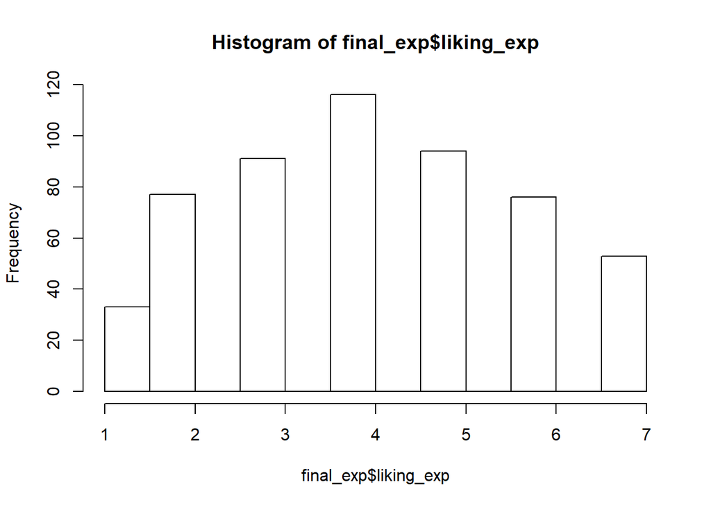

```r
# Non-averaged data:
hist(final_exp$liking_exp)
```

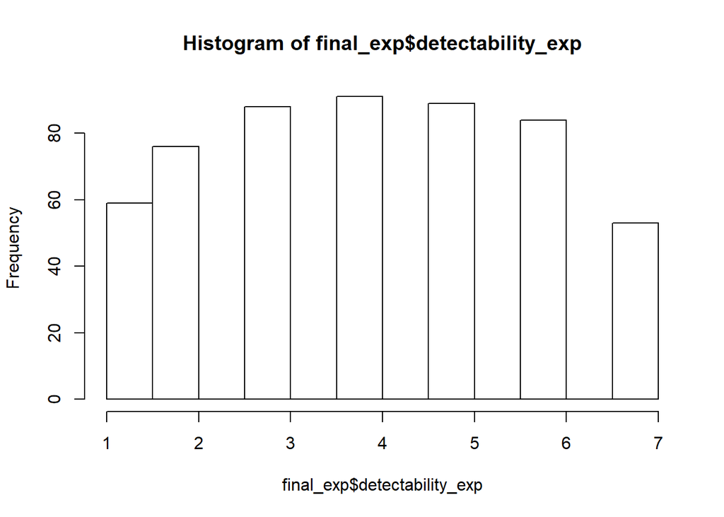

```r
hist(final_exp$detectability_exp)
```

```r
par(mfrow=c(2,2))
typeof(final_exp)
```

```
## [1] "list"
```

```r
mod_exp <- lm(final_exp$liking_exp ~ final_exp$detectability_exp, data=final_exp) #linear regression model
gvlma::gvlma(mod_exp) # further tests for assumtions
```

```
##
## Call:
## lm(formula = final_exp$liking_exp ~ final_exp$detectability_exp,
##     data = final_exp)
##
## Coefficients:
##                 (Intercept)  final_exp$detectability_exp
##                      3.0809                       0.2581
##
##
## ASSESSMENT OF THE LINEAR MODEL ASSUMPTIONS
## USING THE GLOBAL TEST ON 4 DEGREES-OF-FREEDOM:
## Level of Significance =  0.05
##
## Call:
##  gvlma::gvlma(x = mod_exp)
##
##                       Value   p-value                   Decision
## Global Stat        15.89639 0.0031614 Assumptions NOT satisfied!
## Skewness            0.03388 0.8539555    Assumptions acceptable.
## Kurtosis           12.20790 0.0004759 Assumptions NOT satisfied!
## Link Function       3.48267 0.0620146    Assumptions acceptable.
## Heteroscedasticity  0.17194 0.6783954    Assumptions acceptable.
```

```r
summary(mod_exp) # Show summary to check p-value
```

```
##
## Call:
## lm(formula = final_exp$liking_exp ~ final_exp$detectability_exp,
##     data = final_exp)
##
## Residuals:
##     Min      1Q  Median      3Q     Max
## -3.8879 -1.3390  0.1121  1.1447  3.6610
##
## Coefficients:
##                             Estimate Std. Error t value Pr(>|t|)
## (Intercept)                  3.08086    0.16867  18.265  < 2e-16 ***
## final_exp$detectability_exp  0.25814    0.03833   6.735 4.22e-11 ***
## ---
## Signif. codes:  0 '***' 0.001 '**' 0.01 '*' 0.05 '.' 0.1 ' ' 1
##
## Residual standard error: 1.637 on 538 degrees of freedom
## Multiple R-squared:  0.07775,    Adjusted R-squared:  0.07604
## F-statistic: 45.36 on 1 and 538 DF,  p-value: 4.224e-11
```

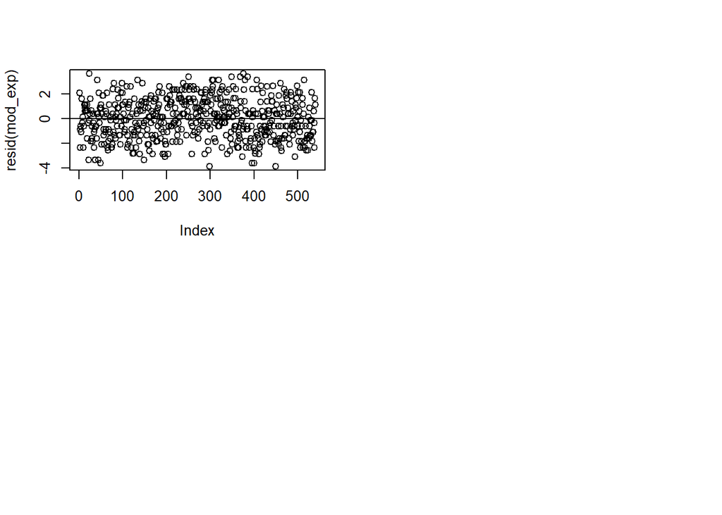

```r
plot(resid(mod_exp)) # Plot residuals to check if normality assumption is necessary
abline(a=0,b=0)
```

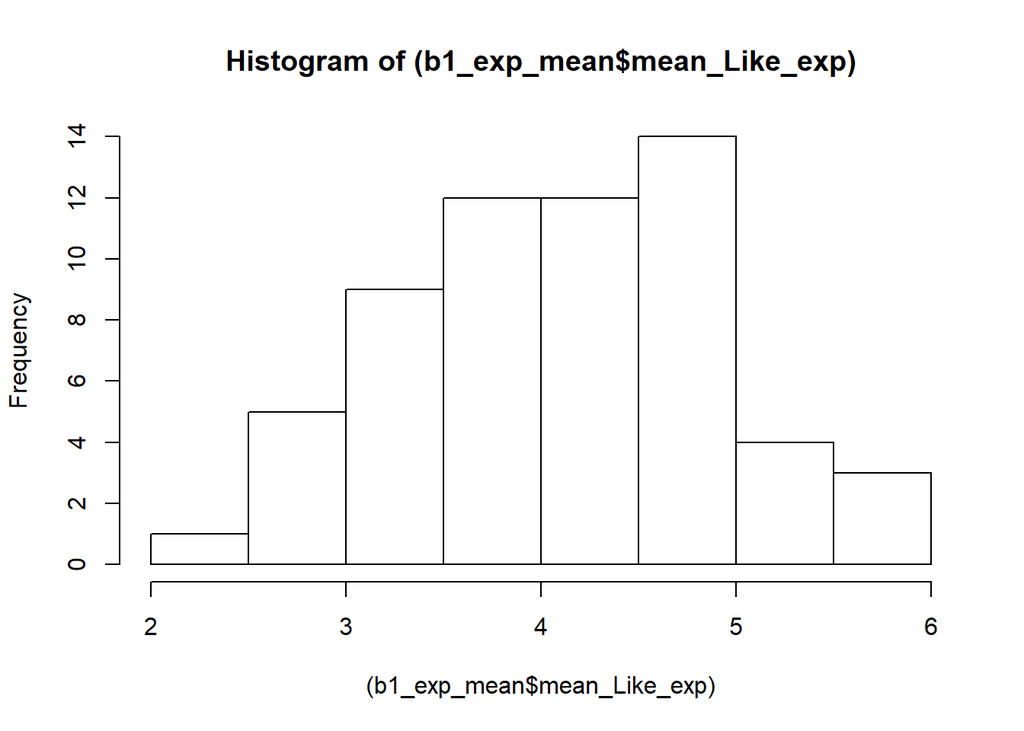

```r
# Averaged data:
hist((b1_exp_mean$mean_Like_exp))
```

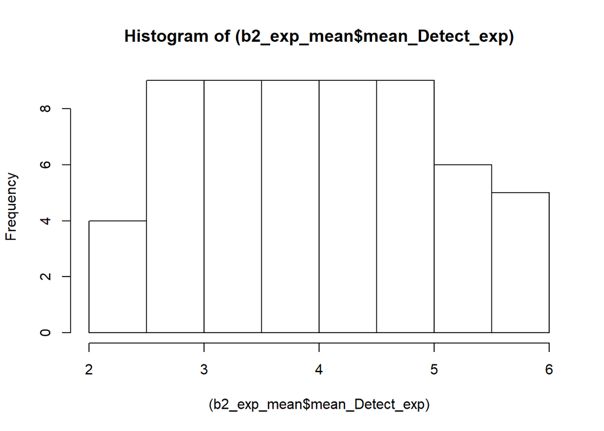

```r
hist((b2_exp_mean$mean_Detect_exp))
```

```r
par(mfrow=c(2,2))
typeof((b1_exp_mean))
```

```
## [1] "list"
```

```r
mod_mean_exp <- lm((b1_exp_mean$mean_Like_exp) ~ (b2_exp_mean$mean_Detect_exp), data=final_exp_mean) # linear regression model
gvlma::gvlma(mod_mean_exp) # further tests for assumtions
```

```
##
## Call:
## lm(formula = (b1_exp_mean$mean_Like_exp) ~ (b2_exp_mean$mean_Detect_exp),
##     data = final_exp_mean)
##
## Coefficients:
##                 (Intercept)  b2_exp_mean$mean_Detect_exp
##                      1.9163                       0.5494
##
##
## ASSESSMENT OF THE LINEAR MODEL ASSUMPTIONS
## USING THE GLOBAL TEST ON 4 DEGREES-OF-FREEDOM:
## Level of Significance =  0.05
##
## Call:
##  gvlma::gvlma(x = mod_mean_exp)
##
##                      Value p-value                Decision
## Global Stat        4.63592  0.3267 Assumptions acceptable.
## Skewness           0.02317  0.8790 Assumptions acceptable.
## Kurtosis           0.96652  0.3256 Assumptions acceptable.
## Link Function      1.85902  0.1727 Assumptions acceptable.
## Heteroscedasticity 1.78722  0.1813 Assumptions acceptable.
```

```r
summary(mod_mean_exp) # Show summary to check p-value
```

```
##
## Call:
## lm(formula = (b1_exp_mean$mean_Like_exp) ~ (b2_exp_mean$mean_Detect_exp),
##     data = final_exp_mean)
##
## Residuals:
##      Min       1Q   Median       3Q      Max
## -1.60234 -0.29832 -0.07182  0.28710  1.29621
##
## Coefficients:
##                             Estimate Std. Error t value Pr(>|t|)
## (Intercept)                  1.91635    0.29930   6.403 2.93e-08 ***
## b2_exp_mean$mean_Detect_exp  0.54941    0.07273   7.554 3.44e-10 ***
## ---
## Signif. codes:  0 '***' 0.001 '**' 0.01 '*' 0.05 '.' 0.1 ' ' 1
##
## Residual standard error: 0.5484 on 58 degrees of freedom
## Multiple R-squared:  0.4959, Adjusted R-squared:  0.4872
## F-statistic: 57.06 on 1 and 58 DF,  p-value: 3.439e-10
```

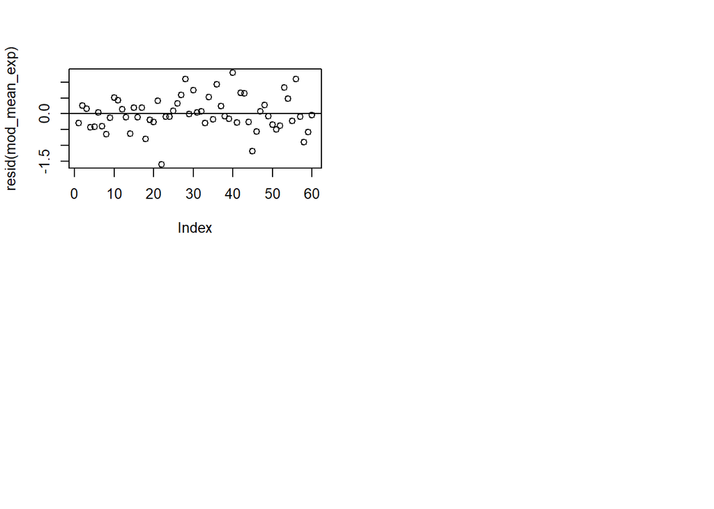

```r
plot(resid(mod_mean_exp)) # Plot residuals to check if normality assumption is necessary
abline(a=0,b=0)
```

## Step 6. Make a plot of the averaged data.

Participants without expecial features:

```r
cor((b2_exp_mean$mean_Detect_exp), (b1_exp_mean$mean_Like_exp))
```

```
## [1] 0.704205
```

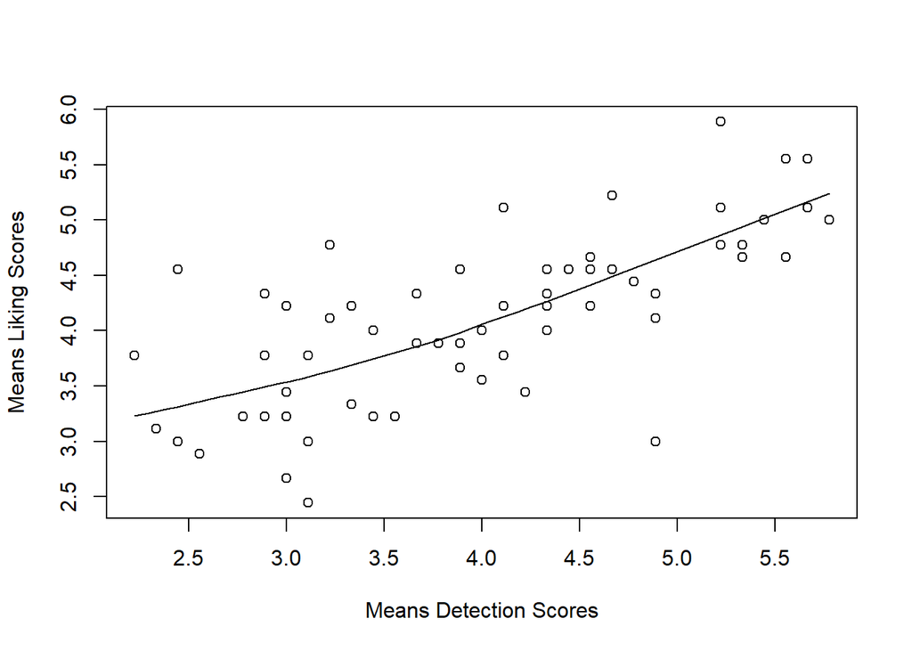

```r
scatter.smooth(y= (b1_exp_mean$mean_Like_exp), x= (b2_exp_mean$mean_Detect_exp), xlab = "Means Detection Scores", ylab = "Means Liking Scores")
```

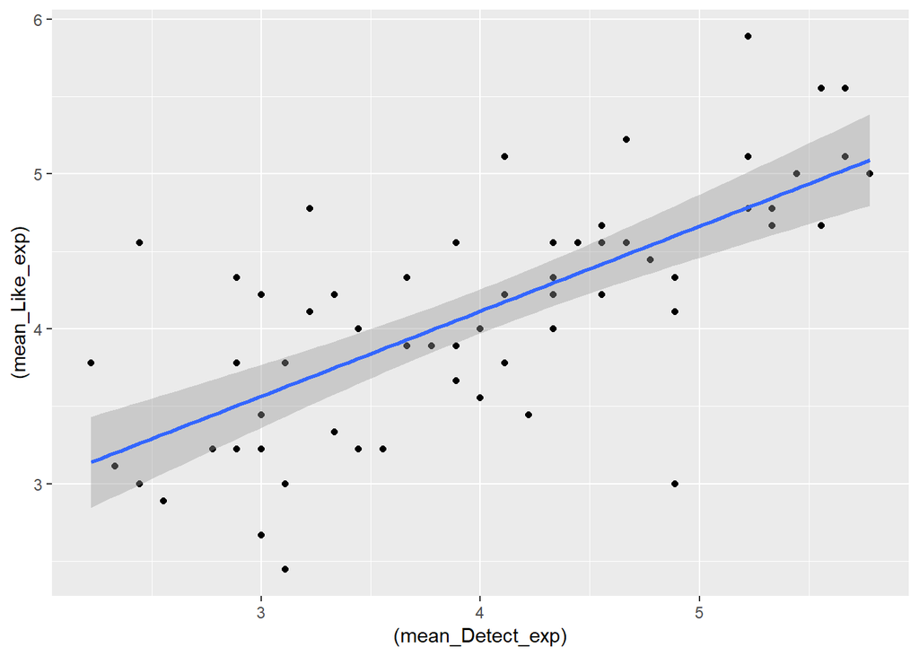

```r
ggplot(final_exp_mean, aes(x = (mean_Detect_exp), y = (mean_Like_exp))) + geom_point() + geom_smooth(method = "lm")
```

Results: The correlation between the two variables Liking and Detectability is positive, but lower than in the original experiment. The lower R-squared value can be explained by outliers.

## Step 7. Run bayesian fixed-effects models

Averaged Data:

```r
brm_exp_gaussian <- brm(formula=mean_Like_exp ~ mean_Detect_exp, data=final_exp_mean, family = "gaussian")
summary(brm_exp_gaussian)
```

```
##  Family: gaussian
##   Links: mu = identity; sigma = identity
## Formula: mean_Like_exp ~ mean_Detect_exp
##    Data: final_exp_mean (Number of observations: 60)
## Samples: 4 chains, each with iter = 2000; warmup = 1000; thin = 1;
##          total post-warmup samples = 4000
##
## Population-Level Effects:
##                 Estimate Est.Error l-95% CI u-95% CI Eff.Sample Rhat
## Intercept           1.92      0.30     1.34     2.52       3174 1.00
## mean_Detect_exp     0.55      0.07     0.40     0.69       3109 1.00
##
## Family Specific Parameters:
##       Estimate Est.Error l-95% CI u-95% CI Eff.Sample Rhat
## sigma     0.56      0.05     0.46     0.68       3553 1.00
##
## Samples were drawn using sampling(NUTS). For each parameter, Eff.Sample
## is a crude measure of effective sample size, and Rhat is the potential
## scale reduction factor on split chains (at convergence, Rhat = 1).
```

Result: Positive correlation.

Non-Averaged data: Cumulative family:

```r
final_exp_mutated <- mutate(final_exp, liking_exp = as.integer(liking_exp), detectability_exp = as.integer(detectability_exp))
show(final_exp_mutated)
```

```
## # A tibble: 540 x 9
##    fileID submission_id   age snellen_result timeSpent liking_exp RT_liking
##     <dbl> <fct>         <dbl>          <dbl>     <dbl>      <int>     <dbl>
##  1      1 613              42              8      9.23          7      5105
##  2      1 547              20             10     39.7           1      6883
##  3      1 620              21              8     10.5           3      4024
##  4      1 742              28             10      9.33          4      4084
##  5      1 753              27              7     12.9           3     14442
##  6      1 755              13             10     11.6           6      3319
##  7      1 458              51              9      8.50          4      2465
##  8      1 459              20              9      4.71          4       836
##  9      1 479              26              4      7.92          4      3064
## 10      2 613              42              8      9.23          2      4060
## # ... with 530 more rows, and 2 more variables: detectability_exp <int>,
## #   RT_detectability <dbl>
```

```r
brm_exp_cumulative <- brm(formula=liking_exp ~ mo(detectability_exp), data=final_exp_mutated, family = "cumulative")
summary(brm_exp_cumulative)
```

```
##  Family: cumulative
##   Links: mu = logit; disc = identity
## Formula: liking_exp ~ mo(detectability_exp)
##    Data: final_exp_mutated (Number of observations: 540)
## Samples: 4 chains, each with iter = 2000; warmup = 1000; thin = 1;
##          total post-warmup samples = 4000
##
## Population-Level Effects:
##                     Estimate Est.Error l-95% CI u-95% CI Eff.Sample Rhat
## Intercept[1]           -1.87      0.27    -2.40    -1.34       2083 1.00
## Intercept[2]           -0.43      0.25    -0.89     0.06       2354 1.00
## Intercept[3]            0.46      0.25    -0.01     0.96       2391 1.00
## Intercept[4]            1.39      0.25     0.91     1.90       2352 1.00
## Intercept[5]            2.25      0.27     1.74     2.77       2266 1.00
## Intercept[6]            3.35      0.29     2.81     3.93       2302 1.00
## modetectability_exp     0.29      0.05     0.19     0.39       2473 1.00
##
## Simplex Parameters:
##                         Estimate Est.Error l-95% CI u-95% CI Eff.Sample
## modetectability_exp1[1]     0.29      0.13     0.03     0.54       2529
## modetectability_exp1[2]     0.17      0.11     0.01     0.41       3157
## modetectability_exp1[3]     0.12      0.09     0.00     0.33       4265
## modetectability_exp1[4]     0.24      0.12     0.03     0.49       3973
## modetectability_exp1[5]     0.12      0.09     0.00     0.32       4272
## modetectability_exp1[6]     0.07      0.06     0.00     0.21       4872
##                         Rhat
## modetectability_exp1[1] 1.00
## modetectability_exp1[2] 1.00
## modetectability_exp1[3] 1.00
## modetectability_exp1[4] 1.00
## modetectability_exp1[5] 1.00
## modetectability_exp1[6] 1.00
##
## Samples were drawn using sampling(NUTS). For each parameter, Eff.Sample
## is a crude measure of effective sample size, and Rhat is the potential
## scale reduction factor on split chains (at convergence, Rhat = 1).
```

Cumulative family for mixed/random effects:

```r
brm_exp_mixed <- brm(formula=liking_exp ~ mo(detectability_exp) + (1|submission_id), data=final_exp_mutated, family = "cumulative")
summary(brm_exp_mixed)
```

```
##  Family: cumulative
##   Links: mu = logit; disc = identity
## Formula: liking_exp ~ mo(detectability_exp) + (1 | submission_id)
##    Data: final_exp_mutated (Number of observations: 540)
## Samples: 4 chains, each with iter = 2000; warmup = 1000; thin = 1;
##          total post-warmup samples = 4000
##
## Group-Level Effects:
## ~submission_id (Number of levels: 9)
##               Estimate Est.Error l-95% CI u-95% CI Eff.Sample Rhat
## sd(Intercept)     0.69      0.25     0.37     1.28       1393 1.00
##
## Population-Level Effects:
##                     Estimate Est.Error l-95% CI u-95% CI Eff.Sample Rhat
## Intercept[1]           -1.95      0.37    -2.70    -1.21       1587 1.00
## Intercept[2]           -0.47      0.35    -1.15     0.24       1563 1.00
## Intercept[3]            0.47      0.35    -0.21     1.17       1579 1.00
## Intercept[4]            1.47      0.36     0.77     2.18       1612 1.00
## Intercept[5]            2.38      0.36     1.68     3.10       1690 1.00
## Intercept[6]            3.55      0.38     2.81     4.31       1761 1.00
## modetectability_exp     0.31      0.05     0.21     0.42       3043 1.00
##
## Simplex Parameters:
##                         Estimate Est.Error l-95% CI u-95% CI Eff.Sample
## modetectability_exp1[1]     0.25      0.12     0.03     0.49       3140
## modetectability_exp1[2]     0.17      0.11     0.01     0.41       4218
## modetectability_exp1[3]     0.11      0.09     0.01     0.32       4862
## modetectability_exp1[4]     0.29      0.12     0.06     0.54       4653
## modetectability_exp1[5]     0.12      0.09     0.00     0.32       4489
## modetectability_exp1[6]     0.05      0.05     0.00     0.18       5237
##                         Rhat
## modetectability_exp1[1] 1.00
## modetectability_exp1[2] 1.00
## modetectability_exp1[3] 1.00
## modetectability_exp1[4] 1.00
## modetectability_exp1[5] 1.00
## modetectability_exp1[6] 1.00
##
## Samples were drawn using sampling(NUTS). For each parameter, Eff.Sample
## is a crude measure of effective sample size, and Rhat is the potential
## scale reduction factor on split chains (at convergence, Rhat = 1).
```

```r
brm_exp_mixed2 <- brm(formula=liking_exp ~ mo(detectability_exp) + (1|submission_id) + (1|fileID), data=final_exp_mutated, family = "cumulative")
summary(brm_exp_mixed2)
```

```
##  Family: cumulative
##   Links: mu = logit; disc = identity
## Formula: liking_exp ~ mo(detectability_exp) + (1 | submission_id) + (1 | fileID)
##    Data: final_exp_mutated (Number of observations: 540)
## Samples: 4 chains, each with iter = 2000; warmup = 1000; thin = 1;
##          total post-warmup samples = 4000
##
## Group-Level Effects:
## ~fileID (Number of levels: 60)
##               Estimate Est.Error l-95% CI u-95% CI Eff.Sample Rhat
## sd(Intercept)     0.42      0.16     0.07     0.72        592 1.00
##
## ~submission_id (Number of levels: 9)
##               Estimate Est.Error l-95% CI u-95% CI Eff.Sample Rhat
## sd(Intercept)     0.71      0.25     0.37     1.30       1006 1.00
##
## Population-Level Effects:
##                     Estimate Est.Error l-95% CI u-95% CI Eff.Sample Rhat
## Intercept[1]           -2.10      0.40    -2.86    -1.32       1747 1.00
## Intercept[2]           -0.59      0.37    -1.31     0.13       1774 1.00
## Intercept[3]            0.39      0.37    -0.33     1.11       1789 1.00
## Intercept[4]            1.42      0.37     0.72     2.15       1808 1.00
## Intercept[5]            2.36      0.38     1.62     3.13       1893 1.00
## Intercept[6]            3.56      0.40     2.79     4.37       2048 1.00
## modetectability_exp     0.29      0.06     0.18     0.41       3212 1.00
##
## Simplex Parameters:
##                         Estimate Est.Error l-95% CI u-95% CI Eff.Sample
## modetectability_exp1[1]     0.28      0.13     0.03     0.53       3849
## modetectability_exp1[2]     0.17      0.11     0.01     0.41       4731
## modetectability_exp1[3]     0.11      0.09     0.00     0.32       6100
## modetectability_exp1[4]     0.26      0.13     0.04     0.52       4315
## modetectability_exp1[5]     0.13      0.09     0.01     0.35       5796
## modetectability_exp1[6]     0.06      0.05     0.00     0.19       5971
##                         Rhat
## modetectability_exp1[1] 1.00
## modetectability_exp1[2] 1.00
## modetectability_exp1[3] 1.00
## modetectability_exp1[4] 1.00
## modetectability_exp1[5] 1.00
## modetectability_exp1[6] 1.00
##
## Samples were drawn using sampling(NUTS). For each parameter, Eff.Sample
## is a crude measure of effective sample size, and Rhat is the potential
## scale reduction factor on split chains (at convergence, Rhat = 1).
```

## Step 8. Compare different bmr models.

```r
loo(brm_exp_cumulative, brm_exp_mixed)
```

```
## Output of model 'brm_exp_cumulative':
##
## Computed from 4000 by 540 log-likelihood matrix
##
##          Estimate   SE
## elpd_loo  -1004.1  9.4
## p_loo         9.6  0.3
## looic      2008.1 18.8
## ------
## Monte Carlo SE of elpd_loo is 0.1.
##
## All Pareto k estimates are good (k < 0.5).
## See help('pareto-k-diagnostic') for details.
##
## Output of model 'brm_exp_mixed':
##
## Computed from 4000 by 540 log-likelihood matrix
##
##          Estimate   SE
## elpd_loo   -984.6 11.8
## p_loo        17.4  0.6
## looic      1969.2 23.5
## ------
## Monte Carlo SE of elpd_loo is 0.1.
##
## All Pareto k estimates are good (k < 0.5).
## See help('pareto-k-diagnostic') for details.
##
## Model comparisons:
##                    elpd_diff se_diff
## brm_exp_mixed        0.0       0.0
## brm_exp_cumulative -19.4       6.5
```

```r
loo(brm_exp_cumulative, brm_exp_mixed2)
```

```
## Output of model 'brm_exp_cumulative':
##
## Computed from 4000 by 540 log-likelihood matrix
##
##          Estimate   SE
## elpd_loo  -1004.1  9.4
## p_loo         9.6  0.3
## looic      2008.1 18.8
## ------
## Monte Carlo SE of elpd_loo is 0.1.
##
## All Pareto k estimates are good (k < 0.5).
## See help('pareto-k-diagnostic') for details.
##
## Output of model 'brm_exp_mixed2':
##
## Computed from 4000 by 540 log-likelihood matrix
##
##          Estimate   SE
## elpd_loo   -982.3 12.0
## p_loo        38.7  1.4
## looic      1964.7 24.0
## ------
## Monte Carlo SE of elpd_loo is 0.1.
##
## All Pareto k estimates are good (k < 0.5).
## See help('pareto-k-diagnostic') for details.
##
## Model comparisons:
##                    elpd_diff se_diff
## brm_exp_mixed2       0.0       0.0
## brm_exp_cumulative -21.7       7.0
```

```r
loo(brm_exp_mixed, brm_exp_mixed2)
```

```
## Output of model 'brm_exp_mixed':
##
## Computed from 4000 by 540 log-likelihood matrix
##
##          Estimate   SE
## elpd_loo   -984.6 11.8
## p_loo        17.4  0.6
## looic      1969.2 23.5
## ------
## Monte Carlo SE of elpd_loo is 0.1.
##
## All Pareto k estimates are good (k < 0.5).
## See help('pareto-k-diagnostic') for details.
##
## Output of model 'brm_exp_mixed2':
##
## Computed from 4000 by 540 log-likelihood matrix
##
##          Estimate   SE
## elpd_loo   -982.3 12.0
## p_loo        38.7  1.4
## looic      1964.7 24.0
## ------
## Monte Carlo SE of elpd_loo is 0.1.
##
## All Pareto k estimates are good (k < 0.5).
## See help('pareto-k-diagnostic') for details.
##
## Model comparisons:
##                elpd_diff se_diff
## brm_exp_mixed2  0.0       0.0
## brm_exp_mixed  -2.3       3.0
```

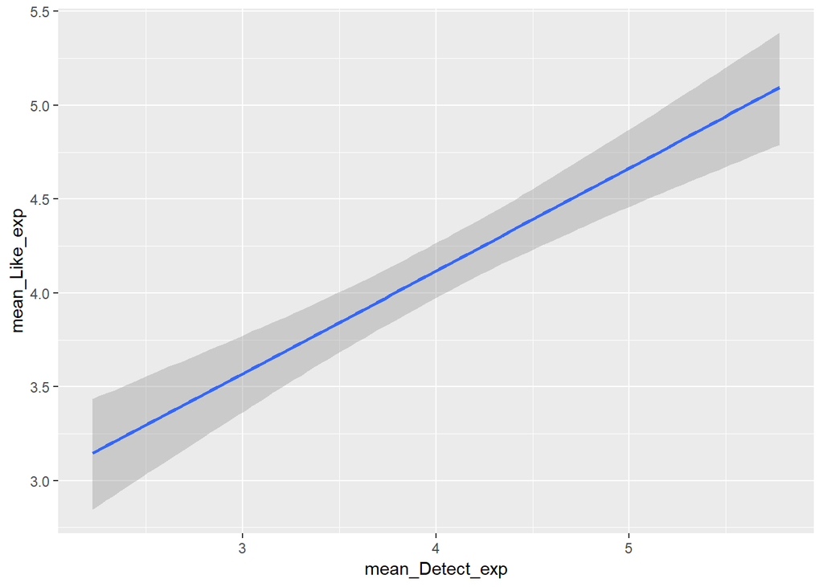

```r
marginal_effects(brm_exp_gaussian)
```

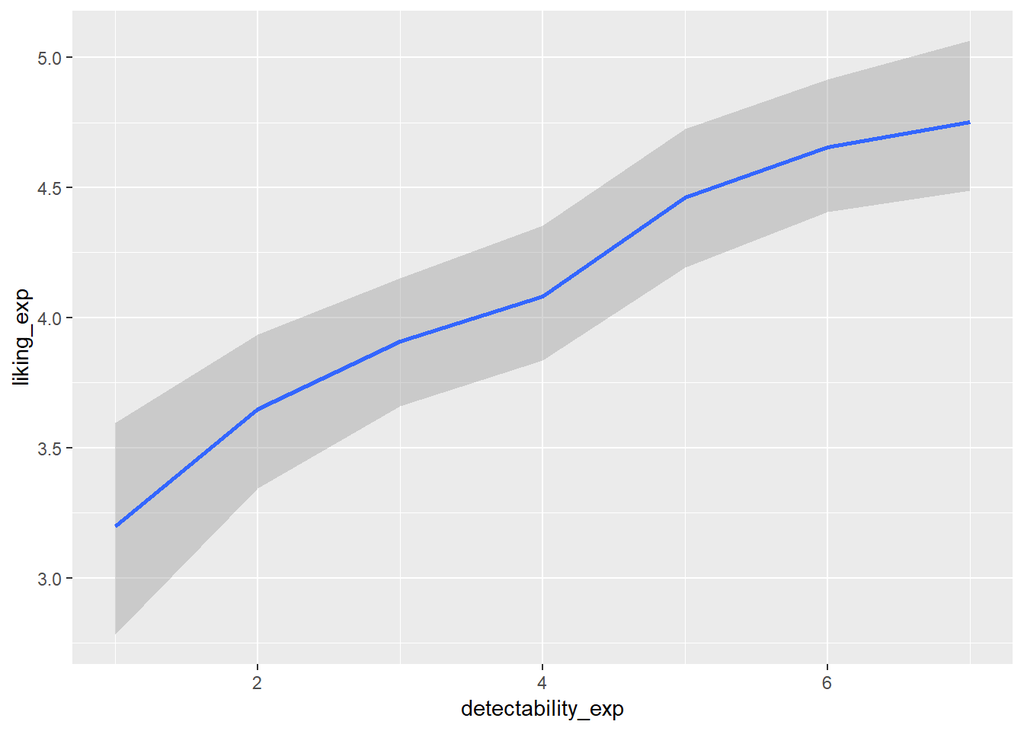

```r
marginal_effects(brm_exp_cumulative)
```

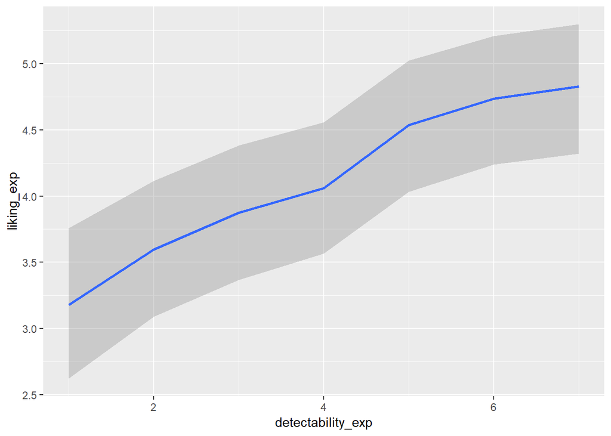

```r
marginal_effects(brm_exp_mixed)
```

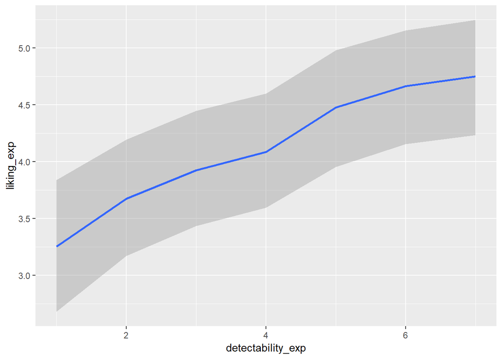

```r
marginal_effects(brm_exp_mixed2)
```